# Which Features of the House Have the Most Influence on its Sale Price?

A Multiple Linear Regression Analysis Using R Programming Language

Fathieh Qakei

2023-12-04

## I. Introduction

### A. Study Design

The real estate market is a complex interplay of various factors that contribute to the valuation of residential properties. Understanding the dynamics of these factors is crucial for making informed decisions for both home buyers and sellers, as well as policymakers and real estate professionals. Various studies have highlighted the significance of factors such as location, property size, and structural attributes in determining property values (Chin and Chau, 2002). The search for a relatively new and relevant dataset that has sufficient sample size of observations proved challenging. However, a comprehensive and contemporary dataset analyzing house prices in Ames city-a city in Story County in the State of Iowa, United States- was found. The Ames housing dataset analyzes 80 predictor variables for 2930 properties sold in Ames, Iowa from 2006 to 2010 (De cock, 2011). Dean De Cock of Truman State University received the Ames housing dataset from the Assessor’s Office. He meticulously compiled the dataset, originally containing 113 variables for 3970 property sales, to align with his teaching objectives. He focused more on 80 predictor variables (23 nominal, 23 ordinal, 14 discrete, and 20 continuous) that explain the physical attributes of a house (De cock, 2011).

### B. Aims

The ultimate purpose of the study is to determine which features of the house have the most significant influence on its sale price.

## II. Methods

### A. Preliminary Model.

A multiple linear regression model is represented by the following equation:
$$Y_i = \beta_0 + \beta_1 X_{i1} +
\beta_2 X_{i2} + \beta_3 X_{i3} + \beta_4 X_{i4} + \beta_5 X_{i5} +
\beta_6 X_{i6} + \beta_7 X_{i7} + \beta_8 X_{i8} + \beta_9 X_{i9} +
\beta_{10} X_{i{10}} + \beta_{11} X_{i{11}} + \beta_{12} X_{i{12}} +
\beta_{13} X_{i{13}} + \beta_{14} X_{i{14}} + \beta_{15} X_{i{15}} +
\beta_{16} X_{i{16}} + \beta_{17} X_{i{17}} + \varepsilon_i$$
, Where:

$Y_i$ is the value of the response variable in the $i$-th house.

$\beta_0$ is the fixed and unknown Y-intercept parameter that represents the expected mean value of the response variable when all predictor variables are zero.

$\beta_1, \beta_2, \ldots, \beta_{17}$ are the coefficients or the fixed and unknown slope parameters for $X_{i1},X_{i2}, \ldots, X_{i17}$ respectively, indicating the change in the response variable for a one-unit change in each predictor variable, holding other predictors constant.

$\varepsilon_i$ is a random error term associated with the ith house and indicates the degree to which $Y_i$ remains unexplained after accounting for the model. $\varepsilon_i$ $\overset{iid}{\sim}$ $\mathcal{N}(0, \sigma^2_{\varepsilon})$, which is read as: the random error $\varepsilon_i$is independently and identically distributed as a normal distribution with mean 0 and variance $\sigma^2_{\varepsilon}$. The variance $\sigma^2_{\varepsilon}$ specifies how much individual values of the random variable $\varepsilon_i$ deviate from the mean (0, in this case).

$X_{i1} =$ number of bedrooms for the $i^{th}$ house, $X_{i2} =$ number of bathrooms for the $i^{th}$ house,  
$X_{i3} =$ size of garage in car capacity for the $i^{th}$ house, $X_{i4} =$ overall material and finish quality for the $i^{th}$ house, $X_{i5} =$ living area square footage for the $i^{th}$ house, $X_{i6} =$ lot area square footage for the $i^{th}$ house, $X_{i7} =$ kitchen quality for the $i^{th}$ house, $X_{i8} =$ heat quality and condition for the $i^{th}$ house, $X_{i9} =$ the availability of central air conditioning for the $i^{th}$ house, , 1 for yes and 0 for no  
$X_{i10} =$ year the $i^{th}$ house was sold $X_{i11} =$ month the $i^{th}$ house was sold $X_{i12} =$ day the $i^{th}$ house was sold $X_{i13} =$ if the $i^{th}$ house style is 1.5 story (One and one-half story: 2nd level finished), 1 for yes and 0 for no $X_{i14} =$ if the $i^{th}$ house style is 1 story finished , 1 for yes and 0 for no $X_{i15} =$ if the $i^{th}$ house style is 2 story finished , 1 for yes and 0 for no $X_{i16} =$ if the $i^{th}$ house style is split foyer , 1 for yes and 0 for no $X_{i17} =$ if the $i^{th}$ house style is split level, 1 for yes and 0 for no

**Explanation of OLS Estimators**

In linear regression, the Ordinary Least Squares (OLS) method aims to find the best-fitting line through a set of data points. The OLS estimators are the values assigned to the coefficients ($\beta_i$) in the regression model, and they are chosen to minimize the least-squares criterion.

The least-squares criterion is defined as the sum of the squared residuals, where the residual for each observation $i$ is the difference between the observed value ($Y_i$) and the predicted value ($\hat{Y}_i$):

$$\text{Residual}(e_i) = Y_i - \hat{Y}_i$$

The least-squares criterion is formulated as:

$$\text{SSE} = \sum_{i=1}^{n} (e_i)^2$$

The goal of OLS is to find the values of the coefficients that minimize this sum across all observations. The resulting OLS estimators represent the coefficients that make the model the best fit to the observed data, striking a balance between accurately representing the data and avoiding overfitting. The OLS estimated model can be expressed as follows:

$\hat{Y}_i = b_0 + b_1 \cdot X_{i1} + b_2 \cdot X_{i2} + b_3 \cdot X_{i3} + b_4 \cdot X_{i4} + b_5 \cdot X_{i5} + b_6 \cdot X_{i6} + b_7 \cdot X_{i7} + b_8 \cdot X_{i8} + b_9 \cdot X_{i9} + b_{10} \cdot X_{i10} + b_{11} \cdot X_{i11} + b_{12} \cdot X_{i12} + b_{13} \cdot X_{i13} + b_{14} \cdot X_{i14} + b_{15} \cdot X_{i15} + b_{16} \cdot X_{i16} + b_{17} \cdot X_{i17}$

where:

$\hat{Y}_i$ is the predicted or estimated value for the $ith$ house, $b_0, b_1, b_2, \ldots, b_{17}$ are the OLS coefficient estimators, $X_{i1}, X_{i2}, \ldots, X_{i17}$ are same values of the independent variables for the $ith$ house defined previously.

**OLS Assumptions**

The effectiveness of OLS relies on several key assumptions as mentioned by Valchanov in his article *Exploring the 5 OLS Assumptions for Linear Regression Analysis* (2021):

The relationship between the independent variables and the dependent variable is assumed to be linear. Additionally, each independent variable is uncorrelated with the error term. This ensures that each predictor contributes independently to the model’s predictions.The error term has a population mean of zero, and observations of the error term are uncorrelated with each other. No pattern exists in the residuals that could be exploited for predicting other residuals. Also, the error term has a constant variance across all levels of the independent variables. This assumption ensures that the spread of residuals remains consistent. No independent variable is perfectly collinear with other variables. This prevents issues with estimating unique coefficients. Finally, the error term is assumed to be normally distributed for valid statistical inference.

Based on automatic variable selection methods in combination with criterion-based statistics, **house_styl**, **dt_sold**, and **central_air** variables were dropped from the model. Partial residual plots, residual-versus-fitted plots, and measures of influence were investigated and cases 79 and 105 were identified as high influence points. The assumptions of linearity, constant variance, independence, and normality of the residuals were met. Details are included in the Appendix.

### B. Final Model

The **final model** is given by:
$$Y_i = \beta_0 + \beta_1 X_{i1} + \beta_2 X_{i2}
+ \beta_3 X_{i3} + \beta_4 X_{i4} + \beta_5 X_{i5} + \beta_6 X_{i6} +
\beta_7 X_{i7} + \beta_8 X_{i8} + \varepsilon_i$$

The estimated (fitted) multiple linear regression model is given by:

$$\hat{Y}_i = 2.249 - 0.04332 \cdot
\text{{bedroom}} + 0.04999 \cdot \text{{bathroom}} + 0.06065 \cdot
\text{{gar\_car}} + 0.1305 \cdot \text{{oa\_qual}} + 0.0002139 \cdot
\text{{liv\_area}} + 0.1559 \cdot \text{{lot\_area}} + 0.05123 \cdot
\text{{kit\_qual}} + 0.03442 \cdot \text{{heat\_qual}}$$

where $\hat{Y}_i$ is the predicted house price for observation $i$, and the coefficients are based on the results obtained from summary table shown in the appendix for the final linear regression model.

## III. Results.

The hypotheses for this statistical analysis are:

The null hypothesis ($H_0$) is defined as follows:
$$H_0: \beta_1 = \beta_2
= \ldots = \beta_{17} = 0$$
The null hypothesis states that none of the independent variables have significant linear relationship with the house sale price.

The corresponding alternative hypothesis ($H_a$) is:
$$H_a: \text{At least one } \beta_i \text{ is not
equal to } 0, \text{ where } i = 1, 2, \ldots, 17$$
The alternative hypothesis asserts that at least one of the coefficients for the independent variables is not equal to zero, which indicates a significant linear relationship with the house sale price.

The final model is now given by:
$$Y_i =
\beta_0 + \beta_1*\ \text{{bedroom}} + \beta_2*\ \text{{bathroom}} +
\beta_3*\ \text{{gar_car}} +
\beta_4*\ \text{{oa_qual}} + \beta_5*\ \text{{liv_area}} + \beta_6* \
\text{{lot_area}} + \beta_7* \ \text{{kit_qual}} + \beta_8* \
\text{{heat_qual}} + \varepsilon_i$$

Finally, from implications of the Analysis of Variance (ANOVA) table for the final model , **bedroom** variable explains 1.25% of the total variation in the house sale price,**bathroom** explains 38.12% , **gar_car** 14.68% ,**oa_qual** 21.80% ,**liv_area** 5.38% ,**lot_area** 4.18% ,**kit_qual** 0.78% , and lastly **heat_qual** explains 0.53% of the total variation in the house sale price. Details are shown in the Appendix.

## V. Appendix

A quick look at what the dataset looks like is printed below:

```
## # A tibble: 6 × 12
##   dt_sold    bedroom bathroom gar_car oa_qual liv_area lot_area house_style
##   <date>       <dbl>    <dbl>   <dbl>   <dbl>    <dbl>    <dbl> <chr>
## 1 2010-03-25       3      2.5       2       6     1479    13517 2Story
## 2 2009-04-10       4      3.5       2       7     2122    11492 2Story
## 3 2010-01-15       3      2         1       5     1057     7922 1Story
## 4 2010-04-19       3      2.5       2       5     1444     9802 2Story
## 5 2010-03-22       3      2         2       6     1445    14235 1.5Fin
## 6 2010-06-06       2      2.5       2       6     1888    16492 1Story
## # ℹ 4 more variables: kit_qual <chr>, heat_qual <chr>, central_air <chr>,
## #   sale_price <dbl>
```

The following summary table of the dataset shows what variables are in the dataset and their ranges. dt_sold: The sales dates range from January 11, 2006, to July 24, 2010. bedroom: The number of bedrooms ranges from 0 to 5. bathroom: The number of bathrooms varies from 1 to 4.5. gar_car: The number of garage spaces ranges from 0 to 4. oa_qual: Overall quality ranges from 2 to 10, with one missing value. liv_area: The living area sizes range from 438 to 3390 square feet. lot_area: Lot area sizes vary between 1533 and 39384 square feet. sale_price: Sale prices range from $44.0 to $545.2 thousand dollars.

These ranges provide a concise overview of the diversity and distribution of the numerical variables in the dataset. Additionally, it highlights any missing values.

```
##     dt_sold              bedroom         bathroom        gar_car
##  Min.   :2006-01-11   Min.   :0.000   Min.   :1.000   Min.   :0.000
##  1st Qu.:2007-02-27   1st Qu.:2.000   1st Qu.:1.500   1st Qu.:1.000
##  Median :2008-04-09   Median :3.000   Median :2.000   Median :2.000
##  Mean   :2008-04-13   Mean   :2.764   Mean   :2.197   Mean   :1.774
##  3rd Qu.:2009-06-03   3rd Qu.:3.000   3rd Qu.:2.500   3rd Qu.:2.000
##  Max.   :2010-07-24   Max.   :5.000   Max.   :4.500   Max.   :4.000
##                                                       NA's   :1
##     oa_qual          liv_area       lot_area     house_style
##  Min.   : 2.000   Min.   : 438   Min.   : 1533   Length:165
##  1st Qu.: 5.000   1st Qu.:1116   1st Qu.: 7288   Class :character
##  Median : 6.000   Median :1450   Median : 9260   Mode  :character
##  Mean   : 6.128   Mean   :1481   Mean   : 9832
##  3rd Qu.: 7.000   3rd Qu.:1707   3rd Qu.:11645
##  Max.   :10.000   Max.   :3390   Max.   :39384
##  NA's   :1
##    kit_qual          heat_qual         central_air          sale_price
##  Length:165         Length:165         Length:165         Min.   : 44.0
##  Class :character   Class :character   Class :character   1st Qu.:130.0
##  Mode  :character   Mode  :character   Mode  :character   Median :157.9
##                                                           Mean   :179.9
##                                                           3rd Qu.:201.6
##                                                           Max.   :545.2
##                                                           NA's   :1
```

The dataset contains four categorical variables which are: house style, kitchen quality, heat quality,and central air.

```
## tibble [165 × 12] (S3: tbl_df/tbl/data.frame)
##  $ dt_sold    : Date[1:165], format: "2010-03-25" "2009-04-10" ...
##  $ bedroom    : num [1:165] 3 4 3 3 3 2 2 3 2 5 ...
##  $ bathroom   : num [1:165] 2.5 3.5 2 2.5 2 2.5 3 2 1 2.5 ...
##  $ gar_car    : num [1:165] 2 2 1 2 2 2 2 2 1 2 ...
##  $ oa_qual    : num [1:165] 6 7 5 5 6 6 6 5 5 5 ...
##  $ liv_area   : num [1:165] 1479 2122 1057 1444 1445 ...
##  $ lot_area   : num [1:165] 13517 11492 7922 9802 14235 ...
##  $ house_style: chr [1:165] "2Story" "2Story" "1Story" "2Story" ...
##  $ kit_qual   : chr [1:165] "Good" "Good" "Good" "Average" ...
##  $ heat_qual  : chr [1:165] "Excellent" "Excellent" "Average" "Good" ...
##  $ central_air: chr [1:165] "Y" "Y" "Y" "Y" ...
##  $ sale_price : num [1:165] 130 NA 109 174 138 ...
```

Relevant time components such as year, month, and day from the **dt_sold** variable are extracted. These components may be used as additional predictors in the model to capture seasonality or trends over different time scales. **house_style** variable is a nominal categorical variable. Thus, One-Hot encoding in R is used to convert the “house_style” column into binary dummy variables. Kitchen quality and heat quality are ordinal categorical variables that have been converted into numerical factors. Finally, Central air variable is converted to binary variable where a value of 1 represents the presence of central air and 0 represent its absence.

There are three missing values in the $\texttt{sahp}$ dataset : one house did not have sale price, another did not specify the overall quality of the house, and the third did not specify the size of garage in car capacity. Since median imputation of NA values is robust to outliers, NA values are replaced with the median value in their column.

A probability density plot of the response variable is shown below. It indicates that the distribution of the **sale_price** data points is right-skewed.

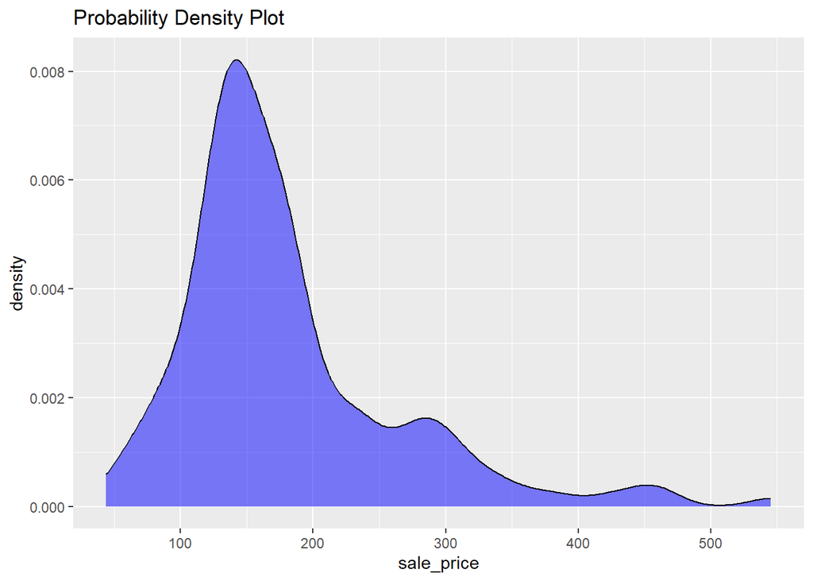

After logarithmic transformation of the response variable, the probability density plot is now closer to a normal distribution:

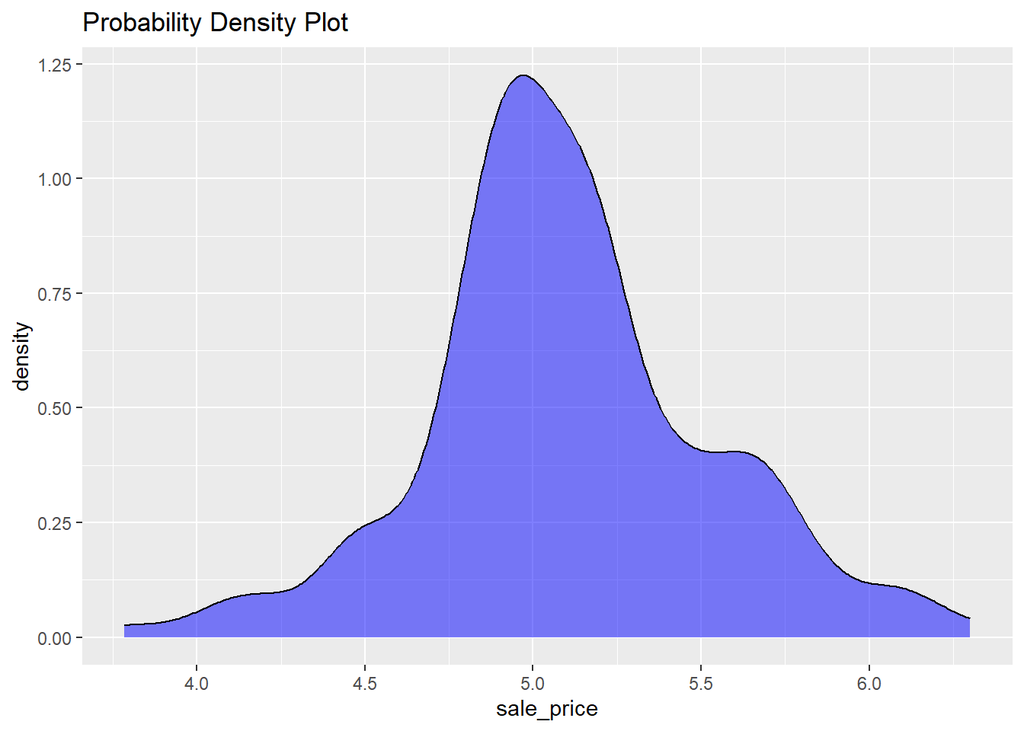

The summary table below shows the preliminary model containing all 17 predictor variables with their coefficients’ estimates, standard error, t values, and probability values. The model shows that split level house style is most likely perfectly multicollinear with other predictor variables, so it is good to drop it early from the model.

```
##
## Call:
## lm(formula = sale_price ~ bedroom + bathroom + gar_car + oa_qual +
##     liv_area + lot_area + kit_qual + heat_qual + central_air +
##     year_sold + mo_sold + day_sold + style[, "house_style1.5Fin"] +
##     style[, "house_style1Story"] + style[, "house_style2Story"] +
##     style[, "house_styleSFoyer"] + style[, "house_styleSLvl"],
##     data = sahp)
##
## Residuals:
##      Min       1Q   Median       3Q      Max
## -0.44802 -0.10067  0.01467  0.08373  0.31838
##
## Coefficients: (1 not defined because of singularities)
##                                Estimate Std. Error t value Pr(>|t|)
## (Intercept)                   2.087e+01  1.916e+01   1.089  0.27780
## bedroom                      -1.396e-02  1.970e-02  -0.709  0.47964
## bathroom                      4.656e-02  2.239e-02   2.079  0.03930 *
## gar_car                       7.117e-02  2.224e-02   3.200  0.00168 **
## oa_qual                       1.171e-01  1.554e-02   7.537 4.44e-12 ***
## liv_area                      2.763e-04  4.977e-05   5.552 1.27e-07 ***
## lot_area                      1.205e-05  2.634e-06   4.575 1.00e-05 ***
## kit_qual                      4.396e-02  2.682e-02   1.639  0.10324
## heat_qual                     3.041e-02  1.540e-02   1.974  0.05020 .
## central_air                   1.876e-01  4.820e-02   3.891  0.00015 ***
## year_sold                    -8.778e-03  9.533e-03  -0.921  0.35870
## mo_sold                      -5.949e-04  3.735e-03  -0.159  0.87367
## day_sold                      1.100e-04  1.651e-03   0.067  0.94696
## style[, "house_style1.5Fin"]  3.075e-02  6.908e-02   0.445  0.65688
## style[, "house_style1Story"]  1.069e-01  5.918e-02   1.806  0.07298 .
## style[, "house_style2Story"] -4.809e-02  6.195e-02  -0.776  0.43886
## style[, "house_styleSFoyer"]  1.249e-01  9.295e-02   1.343  0.18122
## style[, "house_styleSLvl"]           NA         NA      NA       NA
## ---
## Signif. codes:  0 '***' 0.001 '**' 0.01 '*' 0.05 '.' 0.1 ' ' 1
##
## Residual standard error: 0.1549 on 148 degrees of freedom
## Multiple R-squared:  0.8794, Adjusted R-squared:  0.8664
## F-statistic: 67.45 on 16 and 148 DF,  p-value: < 2.2e-16
```

After dropping **house_styleSLvl** variable, the summary table of the model looks as following:

```
##
## Call:
## lm(formula = sale_price ~ bedroom + bathroom + gar_car + oa_qual +
##     liv_area + lot_area + kit_qual + heat_qual + central_air +
##     year_sold + mo_sold + day_sold + style[, "house_style1.5Fin"] +
##     style[, "house_style1Story"] + style[, "house_style2Story"] +
##     style[, "house_styleSFoyer"], data = sahp)
##
## Residuals:
##      Min       1Q   Median       3Q      Max
## -0.44802 -0.10067  0.01467  0.08373  0.31838
##
## Coefficients:
##                                Estimate Std. Error t value Pr(>|t|)
## (Intercept)                   2.087e+01  1.916e+01   1.089  0.27780
## bedroom                      -1.396e-02  1.970e-02  -0.709  0.47964
## bathroom                      4.656e-02  2.239e-02   2.079  0.03930 *
## gar_car                       7.117e-02  2.224e-02   3.200  0.00168 **
## oa_qual                       1.171e-01  1.554e-02   7.537 4.44e-12 ***
## liv_area                      2.763e-04  4.977e-05   5.552 1.27e-07 ***
## lot_area                      1.205e-05  2.634e-06   4.575 1.00e-05 ***
## kit_qual                      4.396e-02  2.682e-02   1.639  0.10324
## heat_qual                     3.041e-02  1.540e-02   1.974  0.05020 .
## central_air                   1.876e-01  4.820e-02   3.891  0.00015 ***
## year_sold                    -8.778e-03  9.533e-03  -0.921  0.35870
## mo_sold                      -5.949e-04  3.735e-03  -0.159  0.87367
## day_sold                      1.100e-04  1.651e-03   0.067  0.94696
## style[, "house_style1.5Fin"]  3.075e-02  6.908e-02   0.445  0.65688
## style[, "house_style1Story"]  1.069e-01  5.918e-02   1.806  0.07298 .
## style[, "house_style2Story"] -4.809e-02  6.195e-02  -0.776  0.43886
## style[, "house_styleSFoyer"]  1.249e-01  9.295e-02   1.343  0.18122
## ---
## Signif. codes:  0 '***' 0.001 '**' 0.01 '*' 0.05 '.' 0.1 ' ' 1
##
## Residual standard error: 0.1549 on 148 degrees of freedom
## Multiple R-squared:  0.8794, Adjusted R-squared:  0.8664
## F-statistic: 67.45 on 16 and 148 DF,  p-value: < 2.2e-16
```

### A. Diagnostics for Predictors.

The following scatterplot matrix indicates positive linear association between lot area and living area.

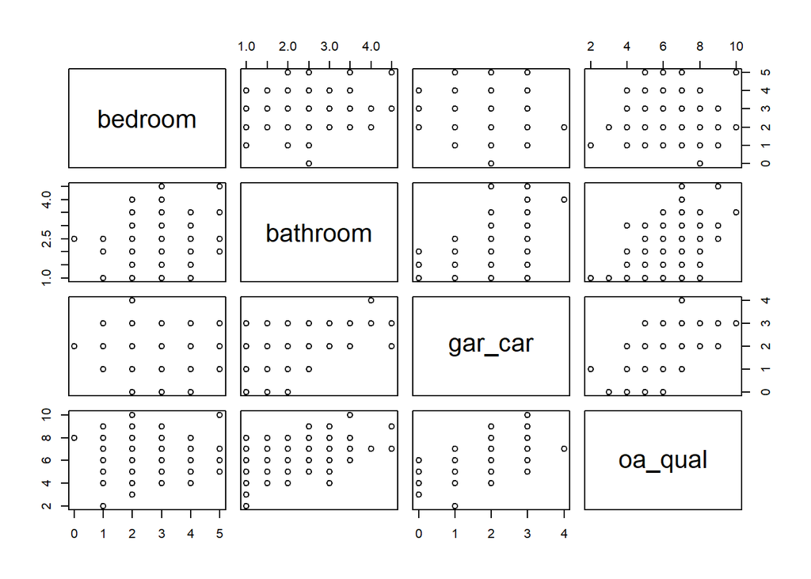

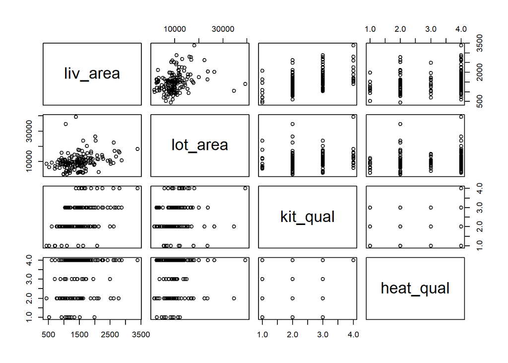

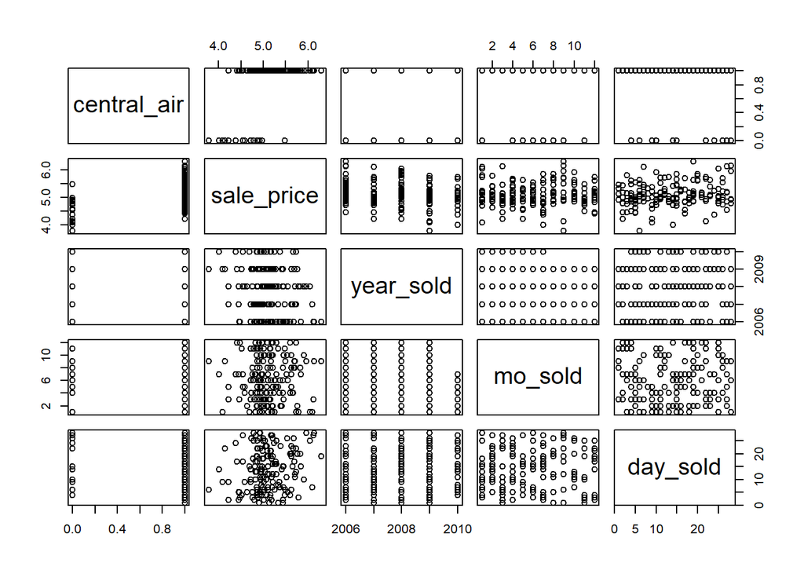

The Pearson correlation coefficients for all pairwise association are shown in the correlation dataframe below. It shows that kitchen quality is highly positively associated with the overall material and and finish quality of the house (r=0.708)

```
##                             bedroom     bathroom     gar_car      oa_qual
## bedroom                  1.00000000  0.147227628  0.04703547  0.033580074
## bathroom                 0.14722763  1.000000000  0.51841880  0.527450886
## gar_car                  0.04703547  0.518418800  1.00000000  0.595628905
## oa_qual                  0.03358007  0.527450886  0.59562891  1.000000000
## liv_area                 0.55389539  0.576210905  0.43492369  0.569664693
## lot_area                 0.10284112  0.162219163  0.26041628  0.103812766
## kit_qual                -0.04703757  0.495999480  0.45217502  0.708220560
## heat_qual               -0.09260708  0.371491791  0.29348199  0.382905086
## central_air             -0.08666859  0.198008682  0.33554666  0.350050681
## sale_price               0.10262664  0.625753712  0.67654958  0.826094702
## year_sold               -0.05121844  0.008076269 -0.10614116 -0.190891001
## mo_sold                  0.15148589  0.117105432  0.01110186  0.016676918
## day_sold                 0.10453003  0.183720303  0.07020602  0.216918169
## style.house_style1.5Fin  0.14169660 -0.244394933 -0.22301155 -0.241452745
## style.house_style1Story -0.39142297 -0.137167527 -0.04538787 -0.002664522
## style.house_style2Story  0.36622692  0.269134431  0.14294911  0.212269710
## style.house_styleSFoyer -0.19061296  0.112359313  0.14565934 -0.041138657
## style.house_styleSLvl    0.05970216  0.032951941  0.02957008 -0.040493075
##                            liv_area     lot_area     kit_qual   heat_qual
## bedroom                  0.55389539  0.102841124 -0.047037565 -0.09260708
## bathroom                 0.57621091  0.162219163  0.495999480  0.37149179
## gar_car                  0.43492369  0.260416283  0.452175022  0.29348199
## oa_qual                  0.56966469  0.103812766  0.708220560  0.38290509
## liv_area                 1.00000000  0.305898758  0.490137139  0.27433543
## lot_area                 0.30589876  1.000000000  0.130077544  0.07434124
## kit_qual                 0.49013714  0.130077544  1.000000000  0.53047798
## heat_qual                0.27433543  0.074341240  0.530477980  1.00000000
## central_air              0.09600425 -0.023583986  0.292489590  0.39923176
## sale_price               0.68147257  0.364245997  0.697359930  0.47875857
## year_sold               -0.10975690 -0.064869431 -0.119830979 -0.08906385
## mo_sold                  0.13277505 -0.058163611 -0.014256403 -0.07065423
## day_sold                 0.16342097  0.007629772  0.203534532  0.03449252
## style.house_style1.5Fin  0.01685644 -0.077327911 -0.167112892  0.02348165
## style.house_style1Story -0.36666233  0.125747157 -0.005160616 -0.07441216
## style.house_style2Story  0.44935360 -0.065654173  0.181069586  0.05948437
## style.house_styleSFoyer -0.10422287 -0.083183198 -0.063446402 -0.02188868
## style.house_styleSLvl   -0.05102597  0.034174766 -0.065473191  0.02695228
##                          central_air   sale_price    year_sold     mo_sold
## bedroom                 -0.086668593  0.102626641 -0.051218444  0.15148589
```

[output cut: 59 more lines]

```
## oa_qual                            -0.041138657           -0.04049307
## liv_area                           -0.104222868           -0.05102597
## lot_area                           -0.083183198            0.03417477
## kit_qual                           -0.063446402           -0.06547319
## heat_qual                          -0.021888685            0.02695228
## central_air                         0.057928445            0.07397109
## sale_price                          0.004627316           -0.04125698
## year_sold                           0.024056261            0.05183726
## mo_sold                             0.073598007           -0.05346628
## day_sold                           -0.048892052           -0.08912323
## style.house_style1.5Fin            -0.067507716           -0.08620324
## style.house_style1Story            -0.173591269           -0.22166546
## style.house_style2Story            -0.116563101           -0.14884397
## style.house_styleSFoyer             1.000000000           -0.03990434
## style.house_styleSLvl              -0.039904344            1.00000000
```

Strip plots for predictors and the dependent variable (jittered) are shown next to boxplots of the same data. First, it should be acknowledged that a log transformation of **sale_price** was taken. There is also skewness visible in the distributions of **lot_area**, with observations clustered below 20000 square feet and a few data points with large values. Natural-log transformation of the **lot_area** variable might be helpful.

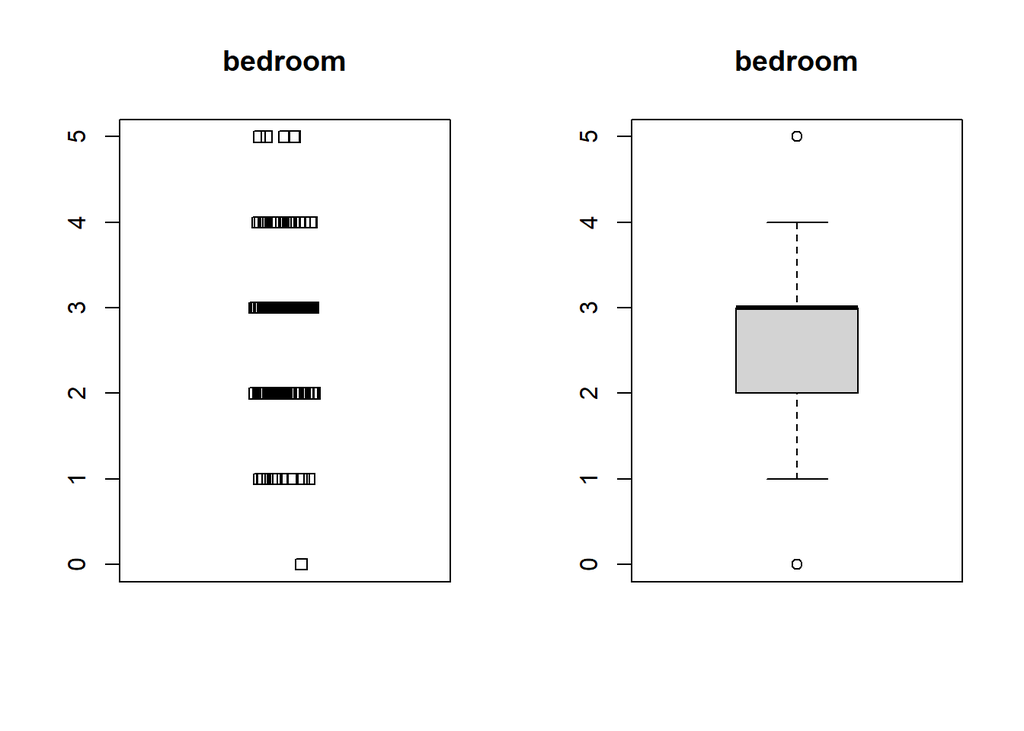

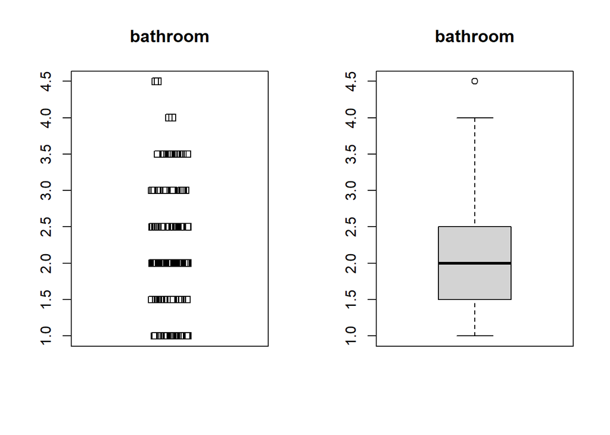

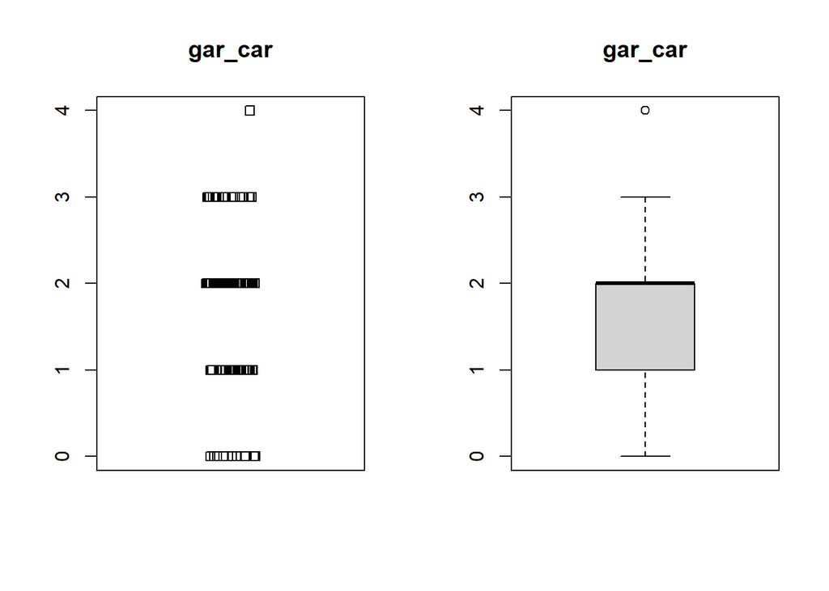

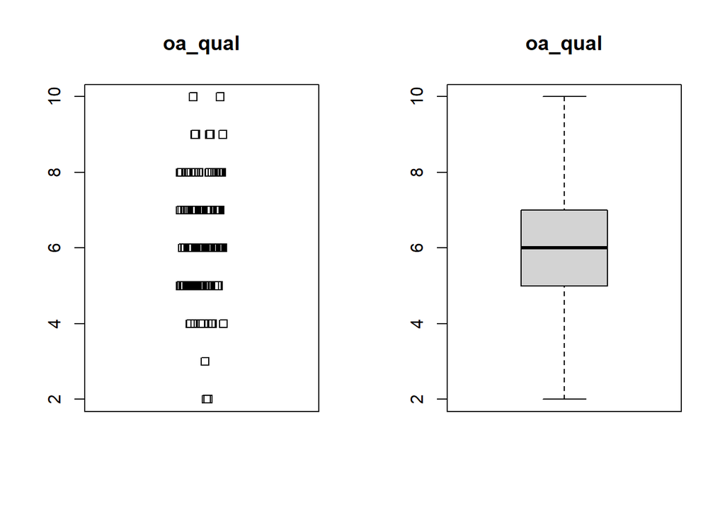

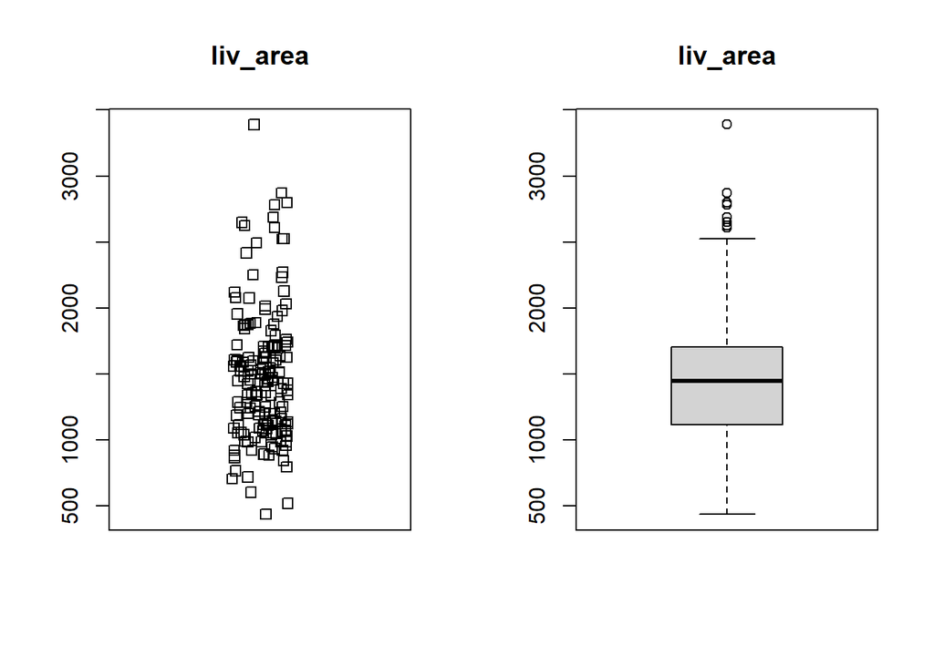

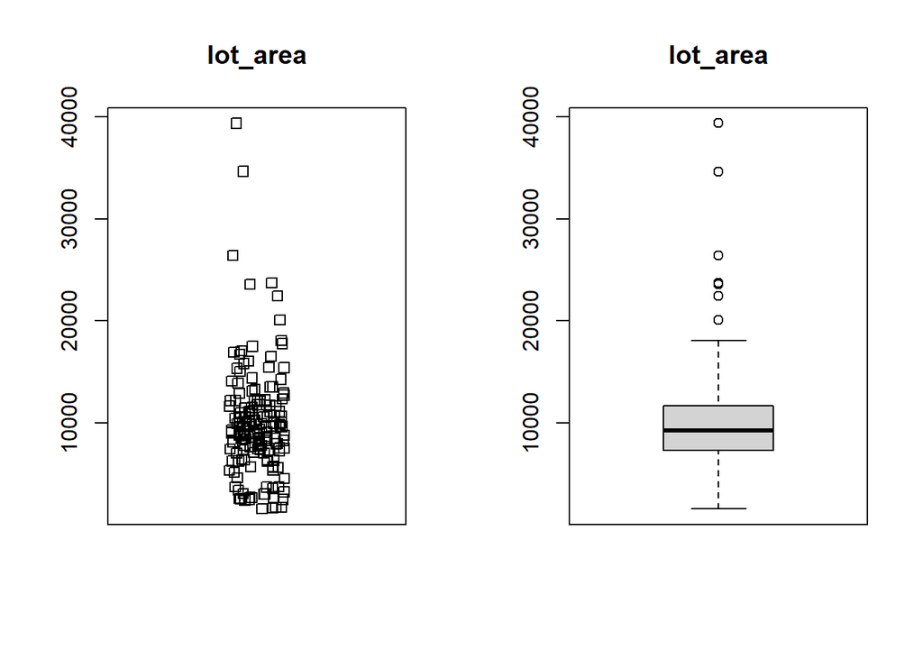

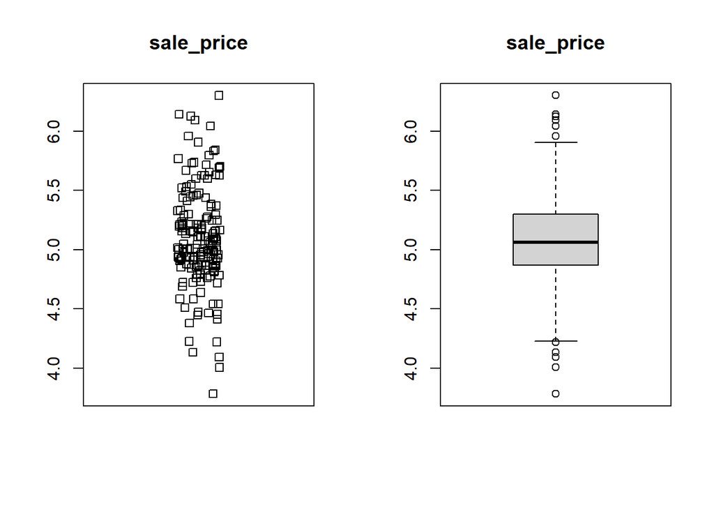

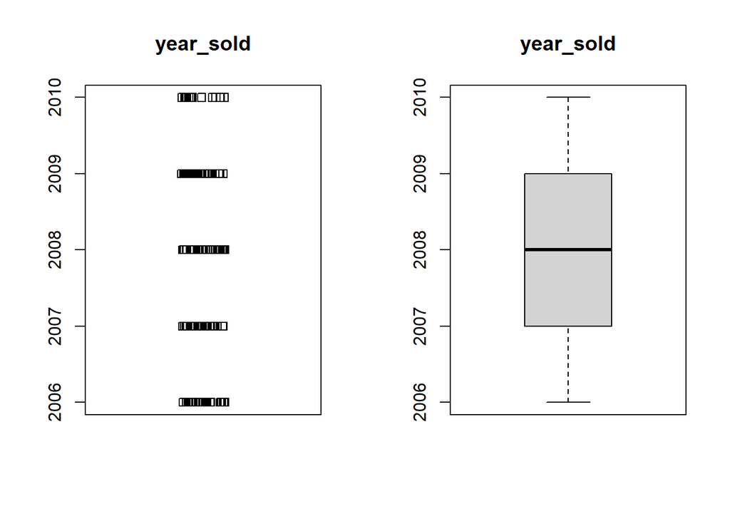

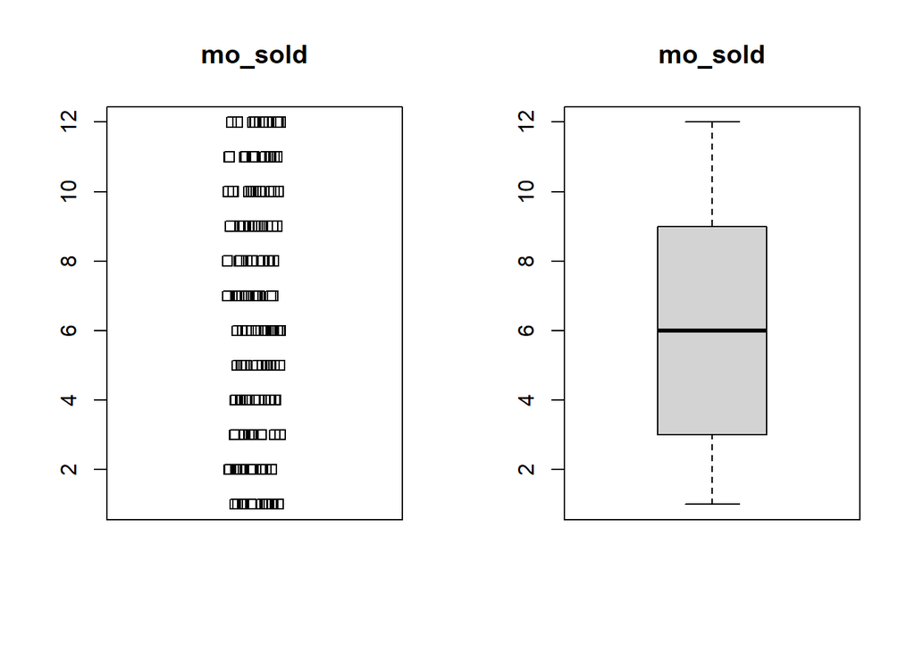

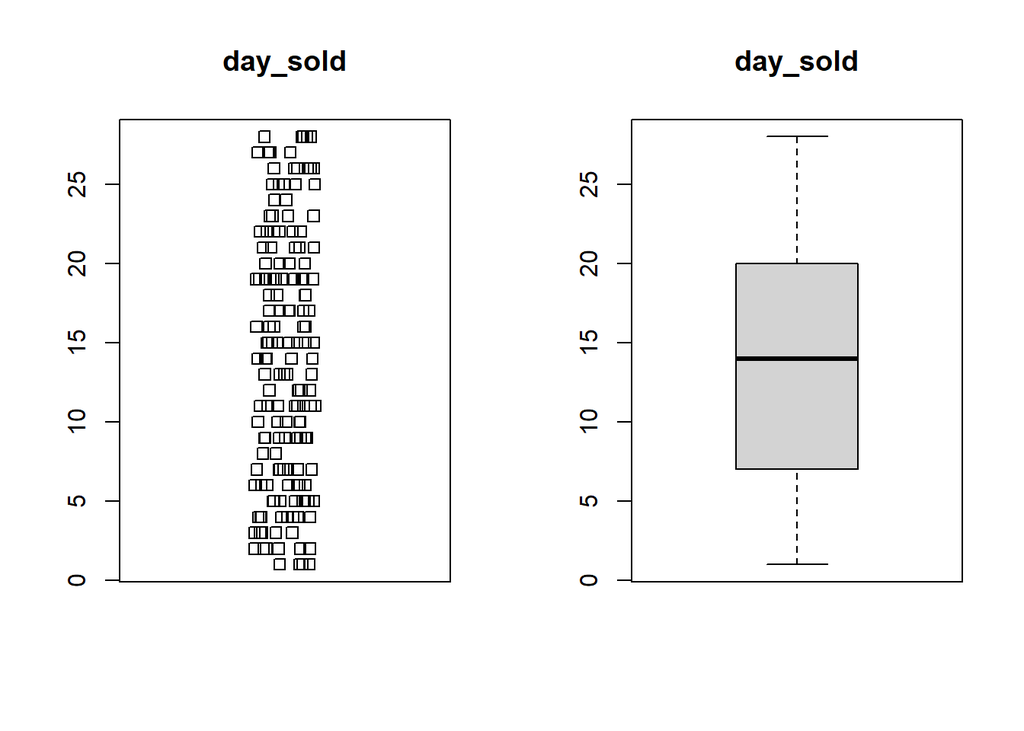

Probability density plot for the **lot_area** shows apparent right skewness in its data distribution.

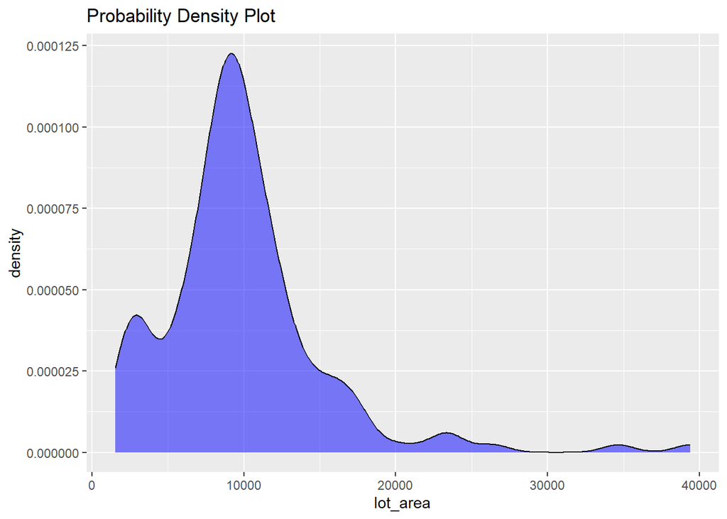

Natural-Log transformation of **lot_area** fixed the skewness and brought its distribution closer to normal.

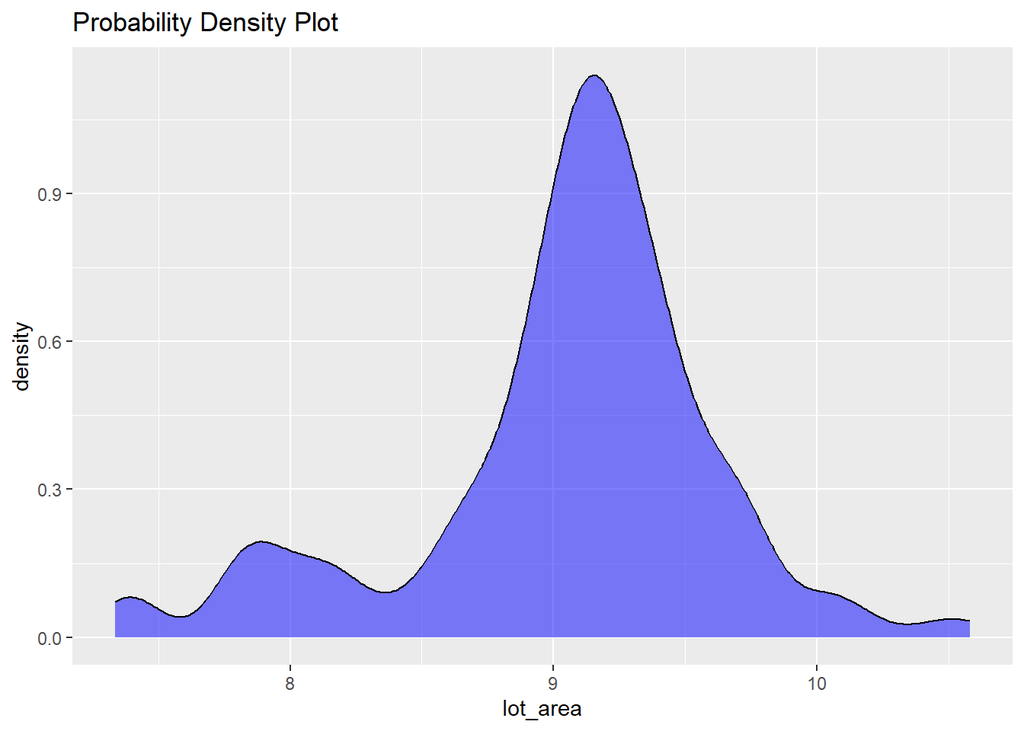

### B. Screening of Predictors

1. Added variable plots for each of the covariates are shown. Added variable plots (also known as partial residual plots or adjusted variable plots) provide evidence of the importance of a covariate given the other covariates already in the model. They also display the nature of the relationship between the covariate and the outcome (i.e., linear, curvilinear, transformation necessary, etc.) and any problematic data points with respect to the predictor. The plots below show that **year_sold**, **mo_old**, and **day_old** covariates seem to not provide any added value to the model that already includes all other covariates; the slopes of their linear relationship with the **sale_price** outcome is close to zero. This is expected because the analysis is studying which features or physical attributes of the house explain its price the most; it is not dealing with time series data that predicts house price over time. Additionally, all styles of houses don’t seem to add any value to the model that has all other covariates because the slopes of their linear relationships with the response variable appear to be close to zero..

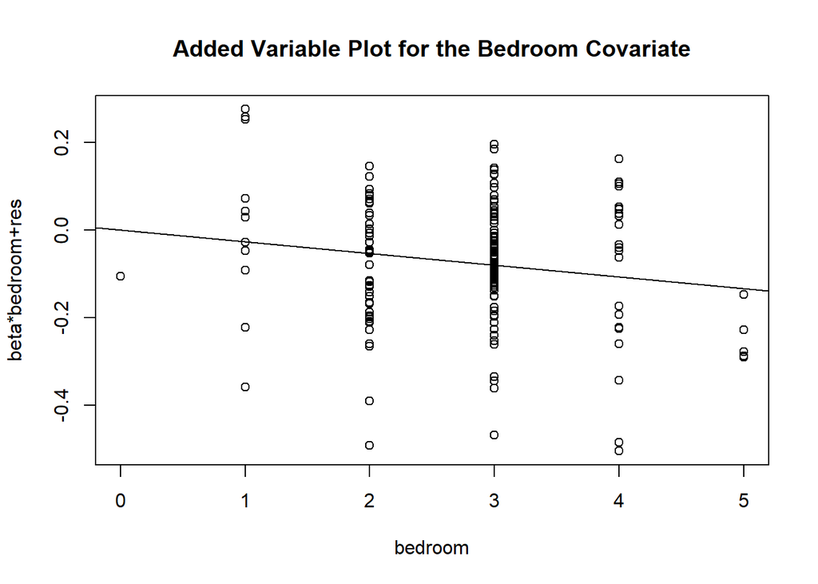

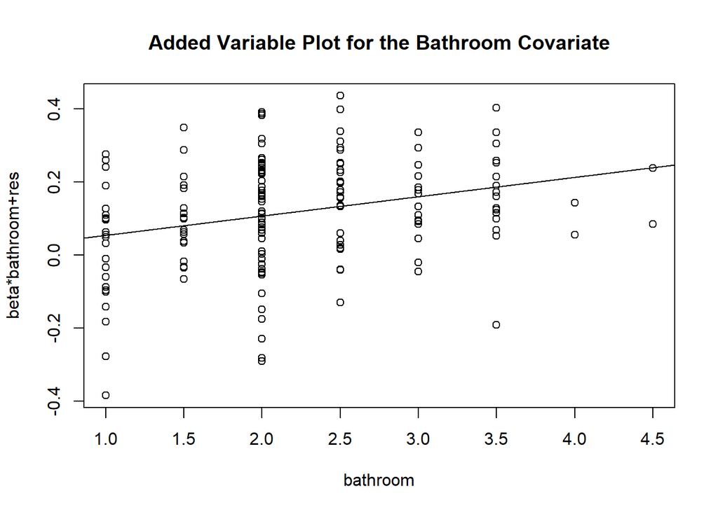

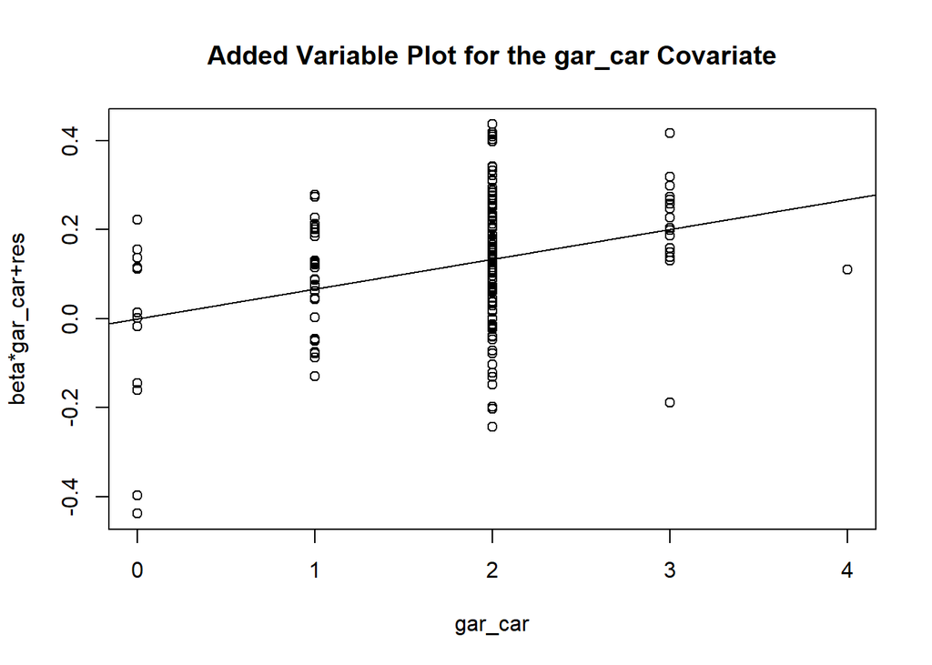

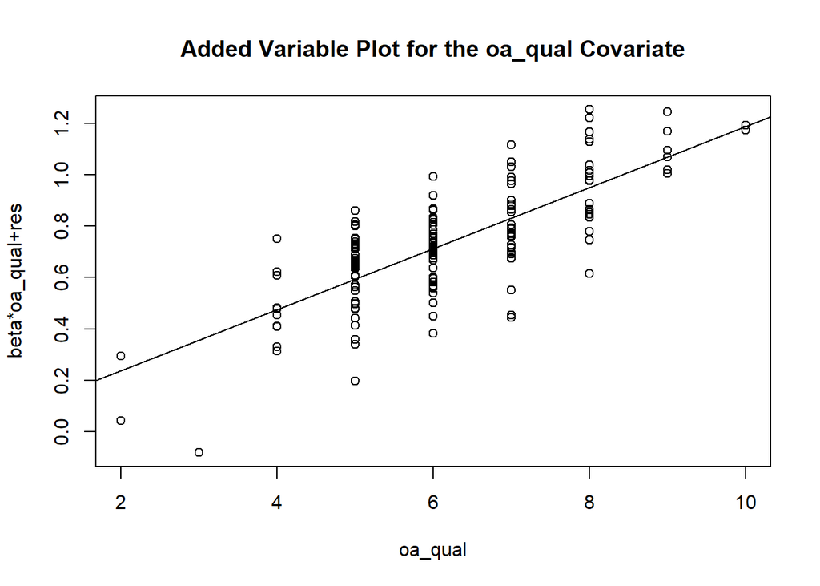

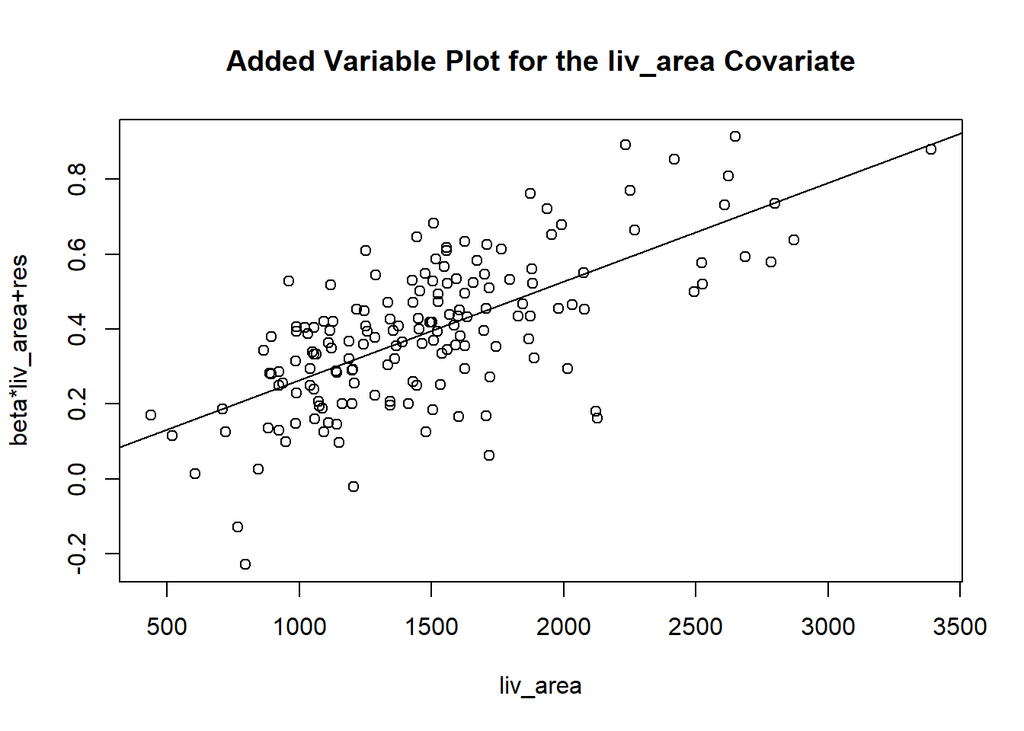

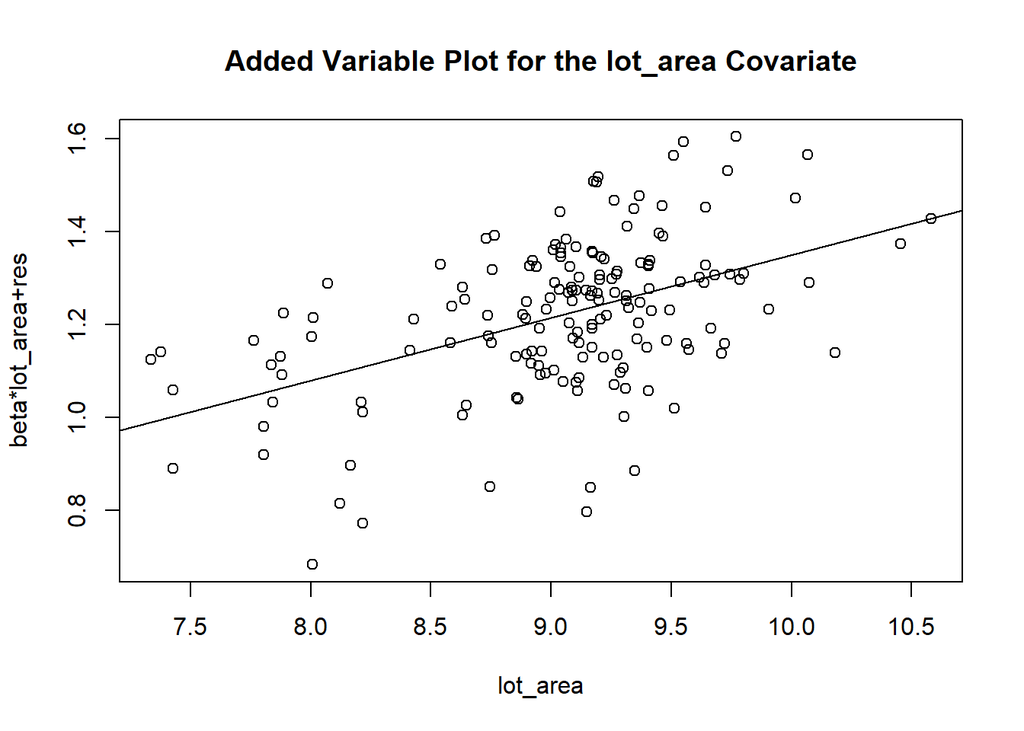

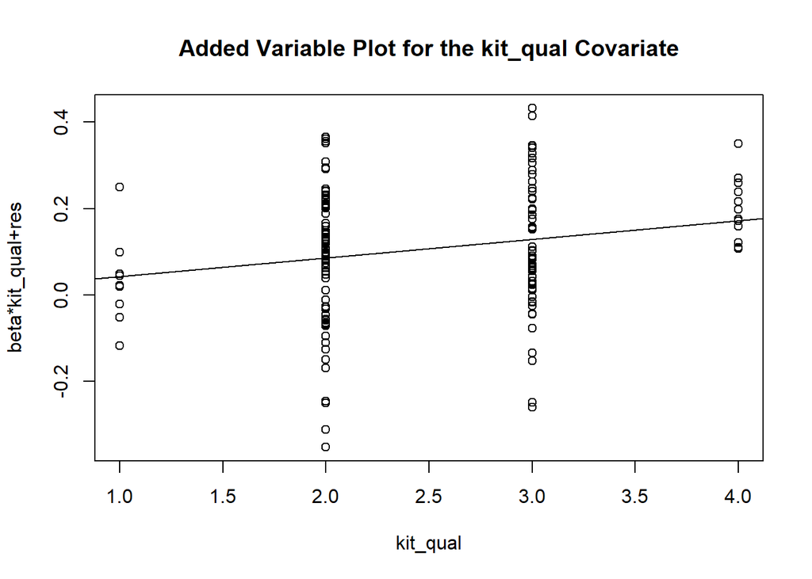

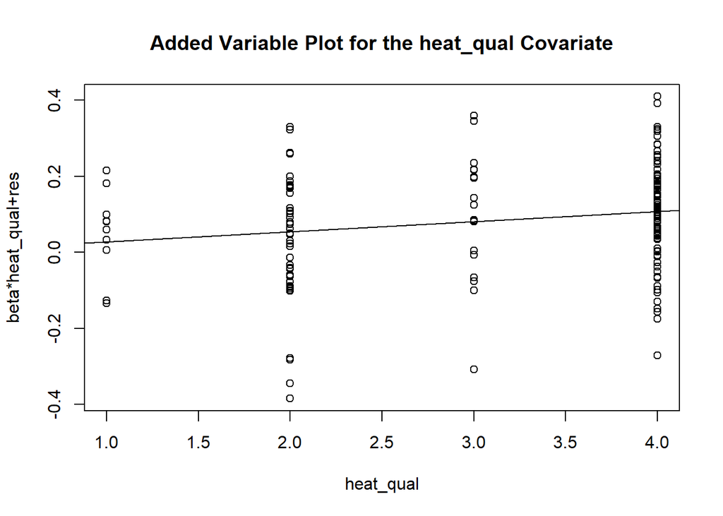

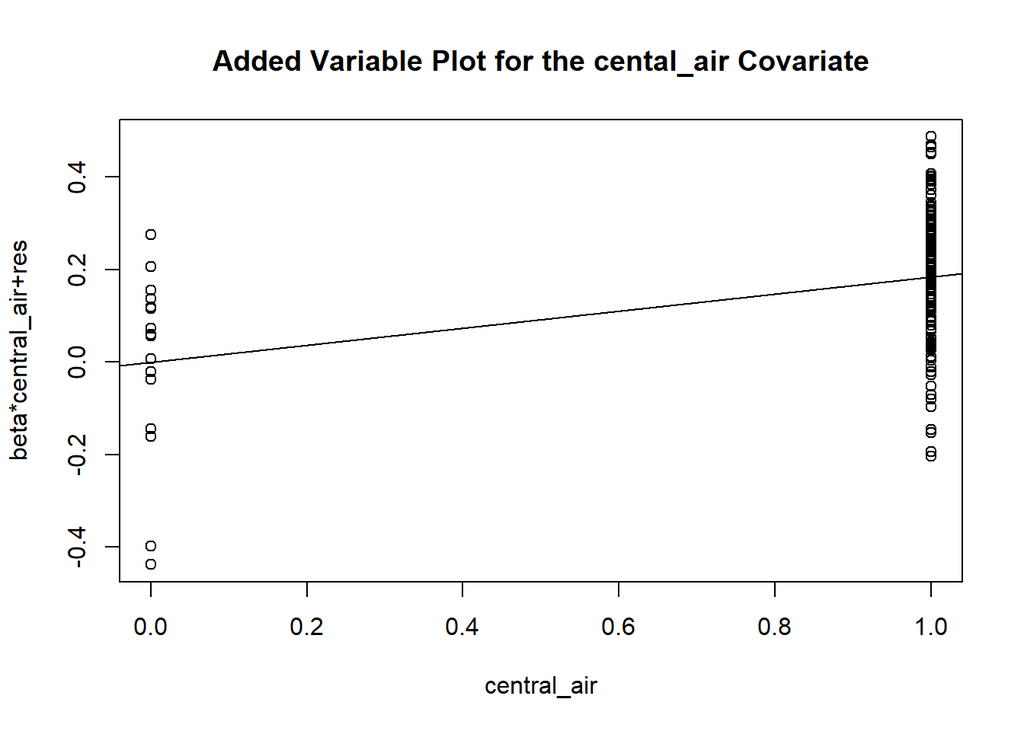

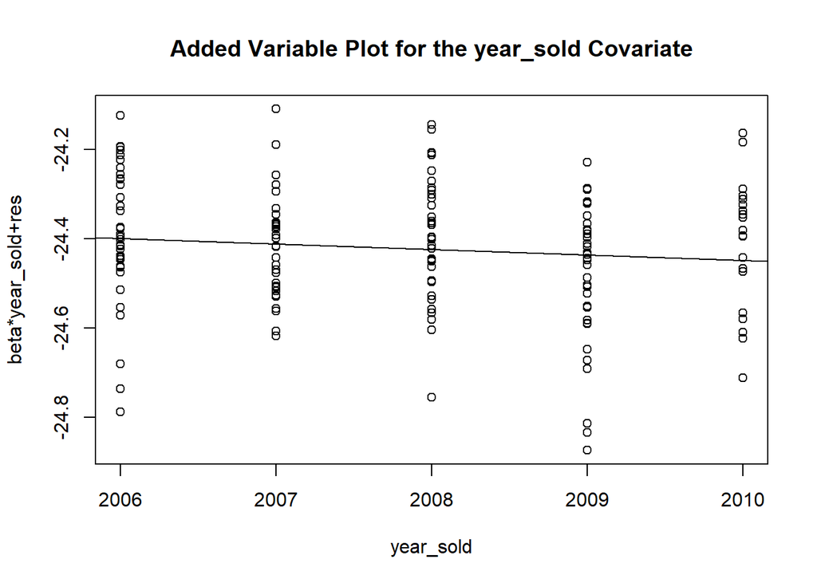

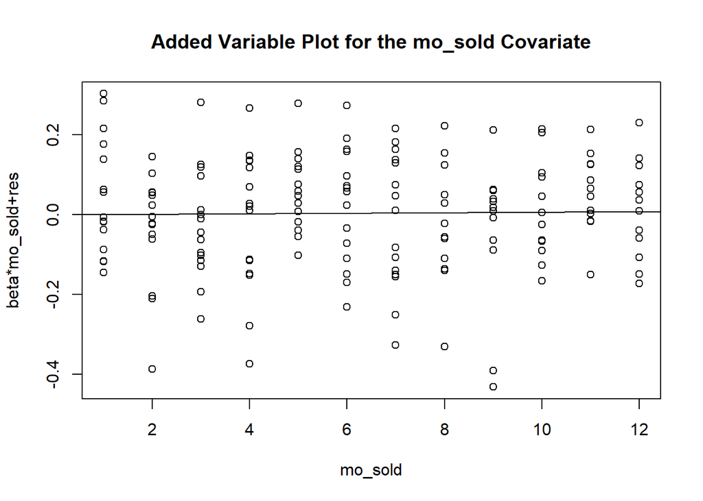

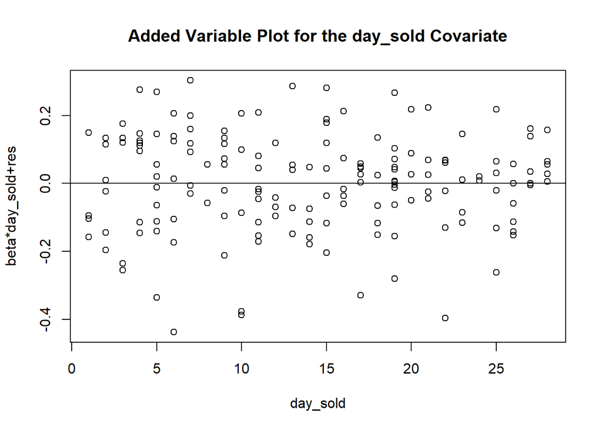

[4 more figures not shown]

2. Multicollinearity can create instability in estimation and so it should be avoided. **Variance inflation factors (VIF)** measure how much the variances of the estimated regression coefficients are inflated as compared to when the predictor variables are not linearly related. A maximum VIF in excess of 5 is a good rule of thumb for multicollinearity problems(Kutner and Nachtsheim, 2014) .A shown in the dataframe below, **house_style1Story** has VIF value of 6.038 and **house_style2Story** has VIF = 5.621, which are larger than the maximum rule of thumb and these two predictor variables may be redundant and need to be dropped from the model.

```
##                               vif(m1)
## bedroom                      2.119153
## bathroom                     2.174730
## gar_car                      1.957197
## oa_qual                      3.267761
## liv_area                     4.220325
## lot_area                     1.461582
## kit_qual                     2.606302
## heat_qual                    1.729128
## central_air                  1.392270
## year_sold                    1.109171
## mo_sold                      1.123991
## day_sold                     1.146826
## style[, "house_style1.5Fin"] 3.610550
## style[, "house_style1Story"] 6.037751
## style[, "house_style2Story"] 5.620673
## style[, "house_styleSFoyer"] 1.729294
```

After dropping **house_style1Story** and **house_style2Story** from the model, **Variance inflation factors (VIF)** for all other variables are reduced as shown below.

```
##                               vif(m2)
## bedroom                      2.012860
## bathroom                     2.159084
## gar_car                      1.949869
## oa_qual                      3.223804
## liv_area                     3.679776
## lot_area                     1.228271
## kit_qual                     2.598390
## heat_qual                    1.715801
## central_air                  1.378971
## year_sold                    1.107619
## mo_sold                      1.120632
## day_sold                     1.124311
## style[, "house_style1.5Fin"] 1.267613
## style[, "house_styleSFoyer"] 1.147294
```

3. **Automatic variable selection methods** will help eliminating possibly more redundant variables. It is used as a guide to the screening and removal (or addition) of predictors. Sequential replacement method is used and the following shows 8 subset regression models with the predictors included in each. The best fitting model will be chosen based on different statistical criteria followed by model validation. These criteria are $R^2_{adj}$ (larger values are better), Bayes Information Criterion $BIC$ (smaller values are better), and Mallow’s $C_p$ statistic (values of $C_p$ close to $p$ (number of beta coefficients) are better).

The automatic variable selection methods showed that the model with 8 predictor variables which are **bedroom**, **bathroom**, **gar_car**, **oa_qual**, **liv_area**, **lot_area**, **kit_qual**, and **heat_qual** had the largest $R^2_{adj}$= 0.852, smallest $BIC$= -277.59, and smallest $C_p$= 21.78. An explanation of each criterion and its results and visualization plots are shown below:

```
## Subset selection object
## Call: regsubsets.formula(sale_price ~ bedroom + bathroom + gar_car +
##     oa_qual + liv_area + lot_area + kit_qual + heat_qual + central_air +
##     year_sold + mo_sold + day_sold + style[, "house_style1.5Fin"] +
##     style[, "house_styleSFoyer"], data = sahp, method = "seqrep")
## 14 Variables  (and intercept)
##                              Forced in Forced out
## bedroom                          FALSE      FALSE
## bathroom                         FALSE      FALSE
## gar_car                          FALSE      FALSE
## oa_qual                          FALSE      FALSE
## liv_area                         FALSE      FALSE
## lot_area                         FALSE      FALSE
## kit_qual                         FALSE      FALSE
## heat_qual                        FALSE      FALSE
## central_air                      FALSE      FALSE
## year_sold                        FALSE      FALSE
## mo_sold                          FALSE      FALSE
## day_sold                         FALSE      FALSE
## style[, "house_style1.5Fin"]     FALSE      FALSE
## style[, "house_styleSFoyer"]     FALSE      FALSE
## 1 subsets of each size up to 8
## Selection Algorithm: 'sequential replacement'
##          bedroom bathroom gar_car oa_qual liv_area lot_area kit_qual heat_qual
## 1  ( 1 ) " "     " "      " "     "*"     " "      " "      " "      " "
## 2  ( 1 ) " "     " "      " "     "*"     " "      "*"      " "      " "
## 3  ( 1 ) " "     "*"      " "     "*"     " "      "*"      " "      " "
## 4  ( 1 ) " "     "*"      " "     "*"     " "      "*"      " "      " "
## 5  ( 1 ) "*"     "*"      "*"     "*"     "*"      " "      " "      " "
## 6  ( 1 ) "*"     "*"      "*"     "*"     "*"      "*"      " "      " "
## 7  ( 1 ) "*"     "*"      "*"     "*"     "*"      "*"      "*"      " "
## 8  ( 1 ) "*"     "*"      "*"     "*"     "*"      "*"      "*"      "*"
##          central_air year_sold mo_sold day_sold style[, "house_style1.5Fin"]
## 1  ( 1 ) " "         " "       " "     " "      " "
## 2  ( 1 ) " "         " "       " "     " "      " "
## 3  ( 1 ) " "         " "       " "     " "      " "
## 4  ( 1 ) "*"         " "       " "     " "      " "
## 5  ( 1 ) " "         " "       " "     " "      " "
## 6  ( 1 ) " "         " "       " "     " "      " "
## 7  ( 1 ) " "         " "       " "     " "      " "
## 8  ( 1 ) " "         " "       " "     " "      " "
##          style[, "house_styleSFoyer"]
## 1  ( 1 ) " "
## 2  ( 1 ) " "
## 3  ( 1 ) " "
## 4  ( 1 ) " "
## 5  ( 1 ) " "
## 6  ( 1 ) " "
## 7  ( 1 ) " "
## 8  ( 1 ) " "
```

1. The adjusted coefficient of multiple determination $R^2_{adj}$.

The coefficient of multiple determination $R^2$ represents the proportion of the total variance in the dependent variable explained by the independent variables, $R^2_{\text{adj}}$ adjusts this value to penalize models with a larger number of predictors, thus providing a more accurate measure of the model’s goodness of fit. Larger value represents better predictive model. Here it is the model that has 8 predictor variables which are: **bedroom**, **bathroom**, **gar_car**, **oa_qual**, **liv_area**, **lot_area**, **kit_qual**, and **heat_qual**

```
## [1] 0.6804842 0.7755717 0.8134863 0.8335074 0.7961697 0.8407344 0.8458682
## [8] 0.8520497
```

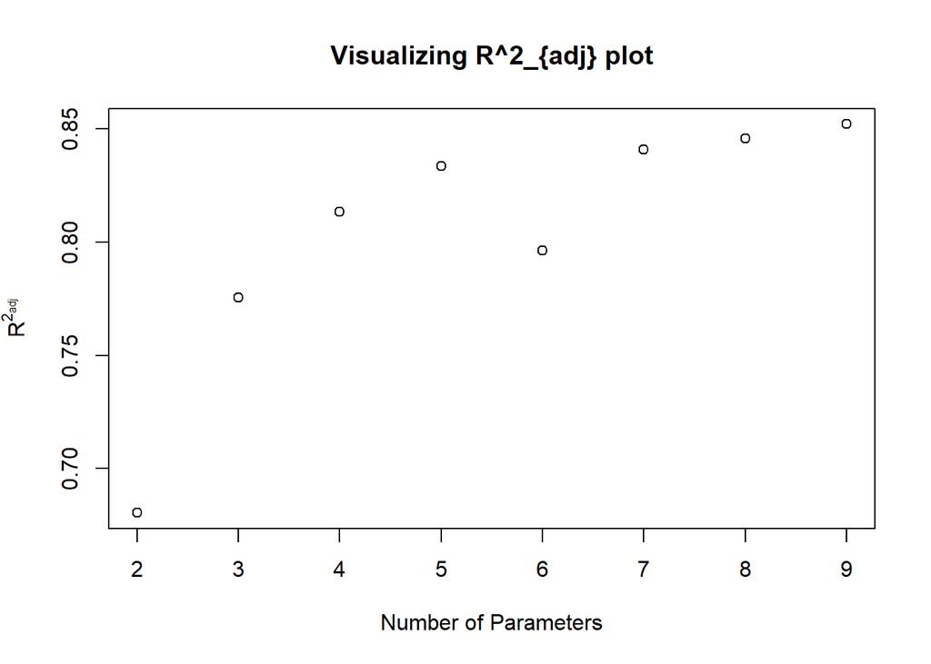

2. The Bayesian Information Criterion (BIC) is another model selection method that penalizes the inclusion of additional predictors in the model. It is given by the formula:

$$BIC = n \cdot \ln(SSE/n) + k \cdot
\ln(n)$$
.

Smaller $BIC$ value represents a better predictive model. Here it is the model that has 8 predictor variables which are: **bedroom**, **bathroom**, **gar_car**, **oa_qual**, **liv_area**, **lot_area**, **kit_qual**, and **heat_qual**

```
## [1] -179.0538 -233.2495 -259.6988 -274.3572 -236.9003 -273.5432 -274.8911
## [8] -277.5933
```

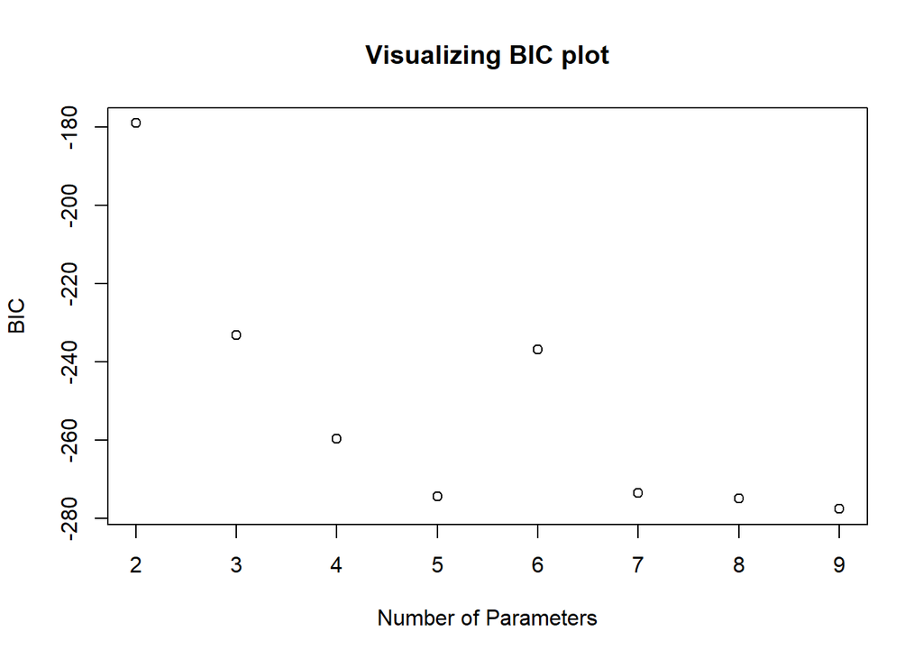

3. Mallows’ $C_p$ criterion measure the total mean squared error of the fitted values for each subset regression model. It helps balance the model’s goodness of fit and model simplicity . It is given by the formula:

$$C_p = \frac{SSE_p}{MSE_{\text{full}}} -
(n - 2p)$$

where $SSE_p$ is the sum of squared errors for the model with $p$ predictors, $MSE_{\text{full}}$ is the mean squared error for the full model, $n$ is the number of observations, and $p$ is the number of predictors. $C_p$ value that is close to $p$ (number of beta coefficients) represents better predictive model. Here, it is the model that has 8 predictor variables which are: **bedroom**, **bathroom**, **gar_car**, **oa_qual**, **liv_area**, **lot_area**, **kit_qual**, and **heat_qual**

```
## [1] 219.85651 106.87292  62.59279  39.80337  83.99938  33.01805  27.95926
## [8]  21.78030
```

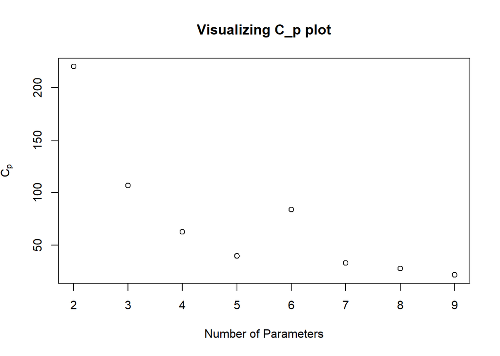

Other criteria not produced by the `regsubsets` function are Akaike’s information criterion $(AIC)$ and Prediction Sum of Squares $(PRESS)$. These statistics are compared for the best two potential subset models resulted from automatic variable selection.

1. $AIC$ is a model selection criteria that penalize models having large numbers of predictors, and given by : The AIC_P (Corrected Akaike Information Criterion) is calculated using the formula:
   $$\text{AIC}_P
   = n \ln(SSE_2) - n \ln(n) + 2p$$
   The model that has smaller $AIC$value is a better predictive model. From the following, the model with 9 parameters is preferred.

```
## The AIC for the reduced model with 9 parameters is: 9 -589.8394 where 9 is the number of parameters (all predictor variables + the intercept) and -589.8394 is the AIC value
```

```
## The AIC for the full model with 8 parameters is: 8 -584.0313 where 8 is the number of parameters (all predictor variables + the intercept) and -584.0313 is the AIC value
```

2. $PRESS$ (Prediction Sum of Squares) assesses the predictive power of a regression model by measuring the sum of squared differences between actual and predicted responses when each observation is excluded from the model. $(PRESS)$ values are shown below. The model with 9 parameters has the lower PRESS value.

```
## [1] 4.698116
```

```
## [1] 4.877617
```

# C.Model Validation

Model validation can help selecting the model that has the best predictive performance in a hold-out sample. There are several approaches to model validation, two of which are shown here.

**Leave-one-out cross validation** involves:

1. Leave out one data point and build the model using the remaining data.
2. Test the model against the data point removed in Step 1 and record the prediction error.
3. Repeat for all data points.
4. Compute the overall prediction error by averaging the prediction errors.
5. If comparing models, the model with lowest MSPE should be selected.

The MSPE is smaller for the model with 8 predictor variables. MSPE is a measure of the average squared difference between the observed values and the values predicted and given by the formula : $MSPE = \frac{1}{n} \sum_{i=1}^{n} (y_i - \hat{y}_i)^2$. RMSE value that is shown below is the square root of the mean squared differences and given by $RMSE = \sqrt{\frac{1}{n} \sum_{i=1}^{n} (y_i - \hat{y}_i)^2}$. Lower values for MSPE or RMSE tell that the model’s predictions align more with the actual data.

```
## Linear Regression
##
## 165 samples
##   8 predictor
##
## No pre-processing
## Resampling: Leave-One-Out Cross-Validation
## Summary of sample sizes: 164, 164, 164, 164, 164, 164, ...
## Resampling results:
##
##   RMSE       Rsquared   MAE
##   0.1687407  0.8405807  0.1320624
##
## Tuning parameter 'intercept' was held constant at a value of TRUE
```

```
## Linear Regression
##
## 165 samples
##   7 predictor
##
## No pre-processing
## Resampling: Leave-One-Out Cross-Validation
## Summary of sample sizes: 164, 164, 164, 164, 164, 164, ...
## Resampling results:
##
##   RMSE      Rsquared   MAE
##   0.171934  0.8344855  0.1315555
##
## Tuning parameter 'intercept' was held constant at a value of TRUE
```

**K-fold cross validation** is useful for large datasets where training and testing data are available/feasible. This method involves:

1. Randomly split the data into $k$ subsets. Reserve one of the subsets for testing.
2. Build (train) the model on the remaining $k-1$ subsets.
3. Test the model on the reserved subset and record the mean squared prediction error.
4. Repeat the process, changing the testing subset each time, until all $k$ subsets have served as the testing set.
5. Calculate the average of the $k$ mean squared prediction errors.
6. If comparing models, the model with the lowest MSPE should be chosen.

The MSPE is smaller for the model with 8 predictor variables

```
## Linear Regression
##
## 165 samples
##   8 predictor
##
## No pre-processing
## Resampling: Cross-Validated (10 fold)
## Summary of sample sizes: 149, 147, 148, 149, 148, 148, ...
## Resampling results:
##
##   RMSE      Rsquared   MAE
##   0.168878  0.8382907  0.1348459
##
## Tuning parameter 'intercept' was held constant at a value of TRUE
```

```
## Linear Regression
##
## 165 samples
##   7 predictor
##
## No pre-processing
## Resampling: Cross-Validated (10 fold)
## Summary of sample sizes: 148, 149, 148, 148, 149, 149, ...
## Resampling results:
##
##   RMSE       Rsquared   MAE
##   0.1690311  0.8497251  0.1327881
##
## Tuning parameter 'intercept' was held constant at a value of TRUE
```